# Lecture 4 Exercises

**1. Continuation of your work on smooth function estimation with the data in curve_data.txt.**

======= Roger’s code:

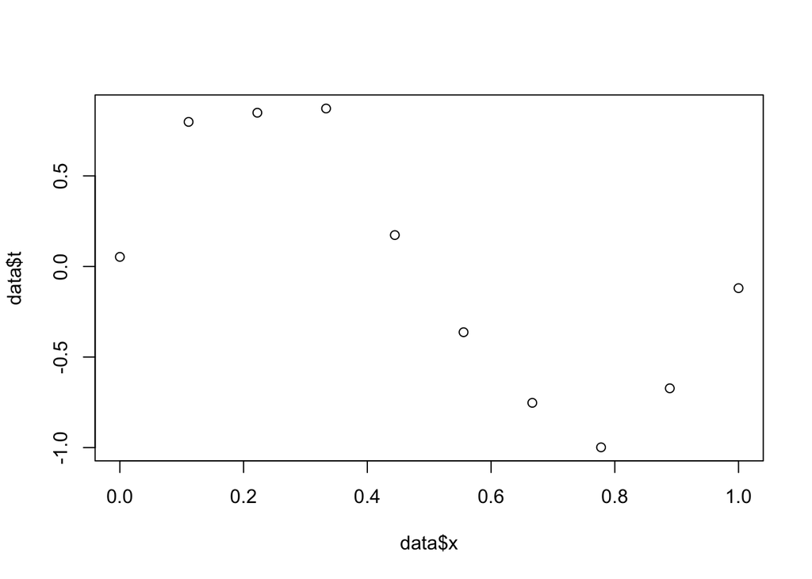

```r
library(MASS)
data <- read.table("curve_data.txt")

plot(data$x, data$t)

phix <- function(x, M, option) {
  phi <- rep(0,M)
  if (option == "poly") {
    for (i in 0:(M)) {
      phi[i+1] <- x**i
    }
  }
  if (option == "Gauss") {
    phi[1] = 1
    for (i in 1:(M)) {
      phi[i+1] <- exp(-((x-i/(M-1))**2)/0.1)
    }

  }
  phi
}


post.params <- function(data, M, option, delta, q) {
  # Q = D + qPhiTPhi
  # wbayes = Q-1(qPhiTt + Dmu)

  phi = phix(data$x[1],M, option)
  for (i in 2:length(data$x)) {
    phi_ <- phix(data$x[i], M, option)
    phi = rbind(phi, phi_)
  }

  Q = diag(delta,M+1) + q*t(phi)%*%phi
  #lambda = delta/q
  w = solve(Q)%*%(q*t(phi)%*%data$t)
  t <- phi%*%w
  return(list(Q,w,t))
}

answer <- post.params(data, 9, "poly", 2.0, (1/0.1)**2)

that <- answer[[3]]

library(ggplot2)
```

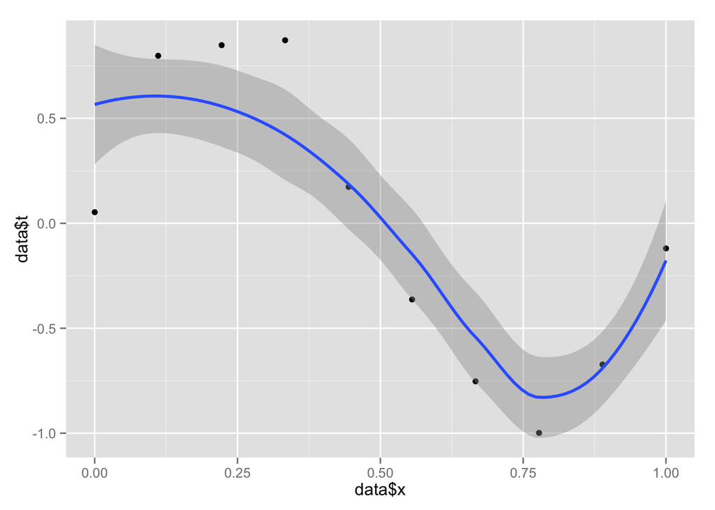

```r
p <- ggplot(cbind(data,that), aes(x=data$x, y=data$t)) + geom_point()
p + stat_smooth(method = "loess", formula = that ~ x, size = 1)
```

```r
dev.off()
```

```r
x <- seq(0,1,1/1000)

precisionBayes <- function(x) {

  precision_w <- post.params(data, 9, "Gauss", 1, (1/0.1)**2)

  phi = phix(x[1],9, "Gauss")
  for (i in 2:length(x)) {
    phi_ <- phix(x[i], 9, "Gauss")
    phi = rbind(phi, phi_)
  }

  Qbayes <- precision_w[[1]]

  mean = phi%*%precision_w[[2]]
  diagonal_matrix <- phi%*%solve(Qbayes)%*%t(phi)+1/((1/0.1)**2)
  var <- diag(diagonal_matrix)
  sd = sqrt(var)

  return(list(mean, sd, diagonal_matrix, phi))

}

mean <- precisionBayes(x)[[1]]
sd <- precisionBayes(x)[[2]]
diagonal_matrix <- precisionBayes(x)[[3]]
phi <- precisionBayes(x)[[4]]

upper_bound <- mean + sd
lower_bound <- mean - sd

bayes_data <- as.data.frame(cbind(mean, upper_bound, lower_bound, x))

#plot_bayes <- ggplot(bayes_data, aes(x = x, y = mean)) + geom_point()
#plot_bayes + stat_smooth(method = "loess", formula = mean ~ x, size = 1) +
#  stat_smooth(method = "loess", formula = upper_bound ~ x, size = 1) +
#  stat_smooth(method = "loess", formula = lower_bound ~ x, size = 1)

plot(data$x, data$t, ylim = range(-1.5:1.5))
lines(predict(splines::interpSpline(x,mean)))
lines(predict(splines::interpSpline(x,lower_bound)))
lines(predict(splines::interpSpline(x,upper_bound)))

dev.off()
```

[output not shown]

```r
# draws <- mvrnorm(100, mu = mean, Sigma = diagonal_matrix)
#
# plot(data$x, data$t, ylim = range(-1.5:1.5))
# for (i in 1:nrow(draws)){
#   lines(predict(splines::interpSpline(x, draws[i,])))
# }
# dev.off()
# mins <- apply(draws, 1, min)
# maxs <- apply(draws, 1, max)
#
# observed_min <- min(data$t)
# observed_max <- max(data$t)
#
# scatterhist <- function(x, y, x1, y1, xlab="", ylab=""){
#   zones=matrix(c(2,0,1,3), ncol=2, byrow=TRUE)
#   layout(zones, widths=c(4/5,1/5), heights=c(1/5,4/5))
#   xhist = hist(x, plot=FALSE)
#   yhist = hist(y, plot=FALSE)
#   top = max(c(xhist$counts, yhist$counts))
#   par(mar=c(3,3,1,1))
#   plot(x,y, col = 'gray', pch = 16)
#   points(x1, y1, col = 'red', pch = 16, cex = 2)
#   par(mar=c(0,3,1,1))
#   barplot(xhist$counts, axes=FALSE, ylim=c(0, top), space=0, col = 'dodgerblue')
#   par(mar=c(3,0,1,1))
#   barplot(yhist$counts, axes=FALSE, xlim=c(0, top), space=0, horiz=TRUE, col = 'dodgerblue')
#   par(oma=c(3,3,0,0))
#   mtext(xlab, side=1, line=1, outer=TRUE, adj=0,
#     at=.8 * (mean(x) - min(x))/(max(x)-min(x)))
#   mtext(ylab, side=2, line=1, outer=TRUE, adj=0,
#     at=(.8 * (mean(y) - min(y))/(max(y) - min(y))))
# }
#
# scatterhist(mins, maxs, observed_min, observed_max)
```

**2.1 Show that the mean of the predictive distribution at an input location x, $φ(x)^{T} w_{Bayes}$ can be represented as $\sum_{n=1}^{N} qφ(x)^{T} Q^{−1}φ(x_{n})t_{n}$ therefore, as a linear combination of the training outputs $t_{n}$.**

We know that the predictive distribution is given by (slide 3):

$t_{N+1}|t,X,x_{N+1} ∼ N(φ(x_{N+1})^{T}w_{Bayes},φ(x_{N+1})^{T}Q^{−1}φ(x_{N+1})+q^{−1})$

From this we know the mean of the predictive distribution at **x** is: $φ(\textbf{x})^{T}w_{Bayes}$

and the equation is given by $w_{Bayes} = qQ^{−1}φ^{T}t$

At **x**, $φ^{T}t$ is $\sum_{n=1}^{N} φ(x_{n})t_{n}$

So we get the final result that the mean of the predictive distribution at **x** is:

$\sum_{n=1}^{N} q φ(x)^{T} Q^{-1} φ(x_{n})t_{n}$

**2.2 The weights above is a quantification of the similarity (in feature space) of the test input x and the training inputs xn. In particular, let $k(x, y) := qφ(x)^{T}Q^{−1}φ(y)$ Then, show that the weight of $t_{n}$ is $k(x,x_{n})$**

We know from 2.1 that the mean of the predictive distribution is given by:

$\bar{x} = \sum_{n=1}^{N} q φ(x)^{T} Q^{-1} φ(x_{n})t_{n}$

We use this to solve for $t_{n}$ and get

$\dfrac{\bar{x}}{\sum_{n=1}^{N} q φ(x)^{T} Q^{-1} φ(x_{n})t} = t_{n}$

We find the summation in the denominator acts as a weight of the mean at **x**.

**3.** IS THIS RIGHT?

We know that:

$k(x, y) := qφ(x)^{T} Q^{−1}φ(y)$

So we can exchange x and y for $x_{n}$ and $x_{k}$

$k(x_{n}, x_{y}) := qφ(x_{n})^{T} Q^{−1}φ(x_{k})$

The matrix produced for all n and all k, e.g. every row of x (n) and every column of x (k) is exactly the matrix K:

$qφ(x_{n})^{T} Q^{−1}φ(x_{k}) = qΦQ^{−1}Φ^{T} = K$

**4. Notice that, by expanding Q,**

$K=q\phi(\delta I+q\phi^{T}\phi)^{−1}\phi^{T} = \phi(\lambda I+\phi^{T}\phi)^{−1}\phi^{T}$.

**Show that when $\lambda = 0$, and provided $\phi^{T}\phi$ is invertible, K is precisely the “hat” matrix of linear regression. Therefore, the matrix of kernel weights provides a Bayesian version of such matrix. We will revisit this later in the course.**

The “Hat” matrix from linear regression is given by:

$H = \phi(\phi^{T}\phi)^{−1}\phi^{T}$

When $\lambda = 0$, the first term in paranthesis:

$K = \phi(\lambda I+\phi^{T}\phi)^{−1}\phi^{T}$

is a matrix of zeroes and thus when multiplied by $\phi$ is still a matrix of zeros so we remove it from the equation and the equation reduces to:

$K = H = \phi(\phi^{T}\phi)^{−1}\phi^{T}$